# GHG and milk yield

## Load data

```r
ghg_variables<- read.csv("MC results/mcSimulationResults.csv")

# select the appropriate variables from the MC outputs names(ghg_variables)

#assuming 'on-farm' is the annual GHG
chill <- ghg_variables$on_farm
#assuming 'kg_FPCM_year-farm' is the annual milk yield
yield <- ghg_variables$kg_FPCM_year
```

## Scatter plot

Using `chillscatter()` create a chill portions (x) and yield (y) scatter plot with associated and estimated densities with loess smooth linear fits density curves. Plot made with the scatter.hist() function in the plyr() package (Wickham 2011) in R (R Core Team 2017).

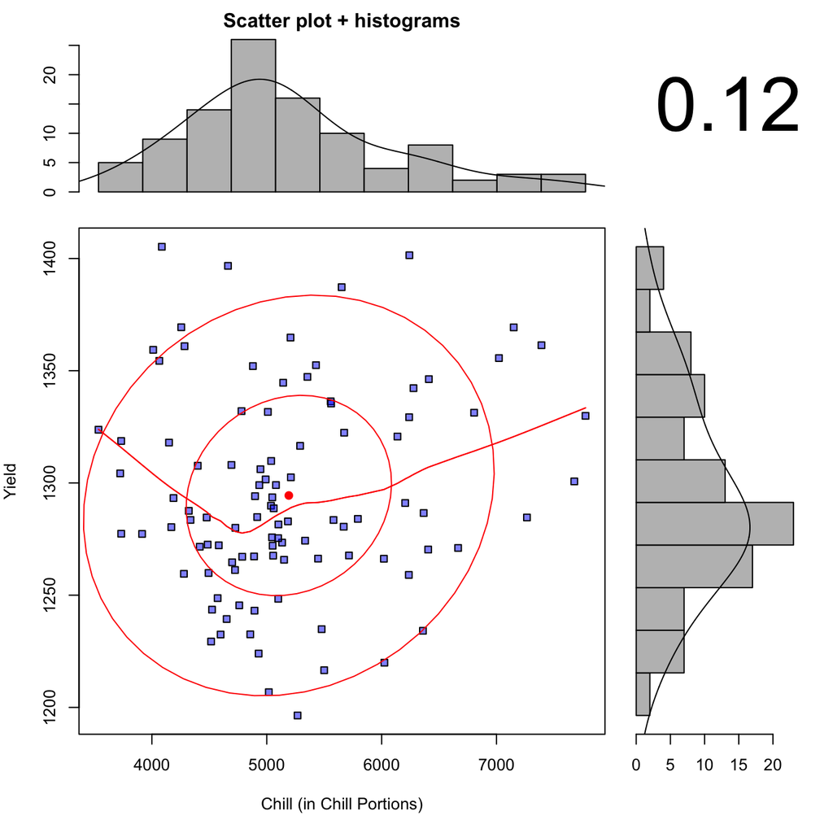

```
#> [1] "Chill (x) and yield (y) scatter plot with associated and estimated densities."
```

```r
pasitR::chillscatter(chill, yield)
```

## Kernel plot

Use `chillkernel()` or another type of graphical representation of the same relationship. `chillkernel()` performs a two-dimensional kernel density estimation for yield and chill using the `kde2d()` function in the `MASS()` package (Venables and Ripley 2002). The function produces a matrix of the estimated density (z) of yield (y) and chill (x). As the density function restricts the shape of the kernel to a bivariate normal kernel, it looks slightly different compared to the scatter plot estimates above.

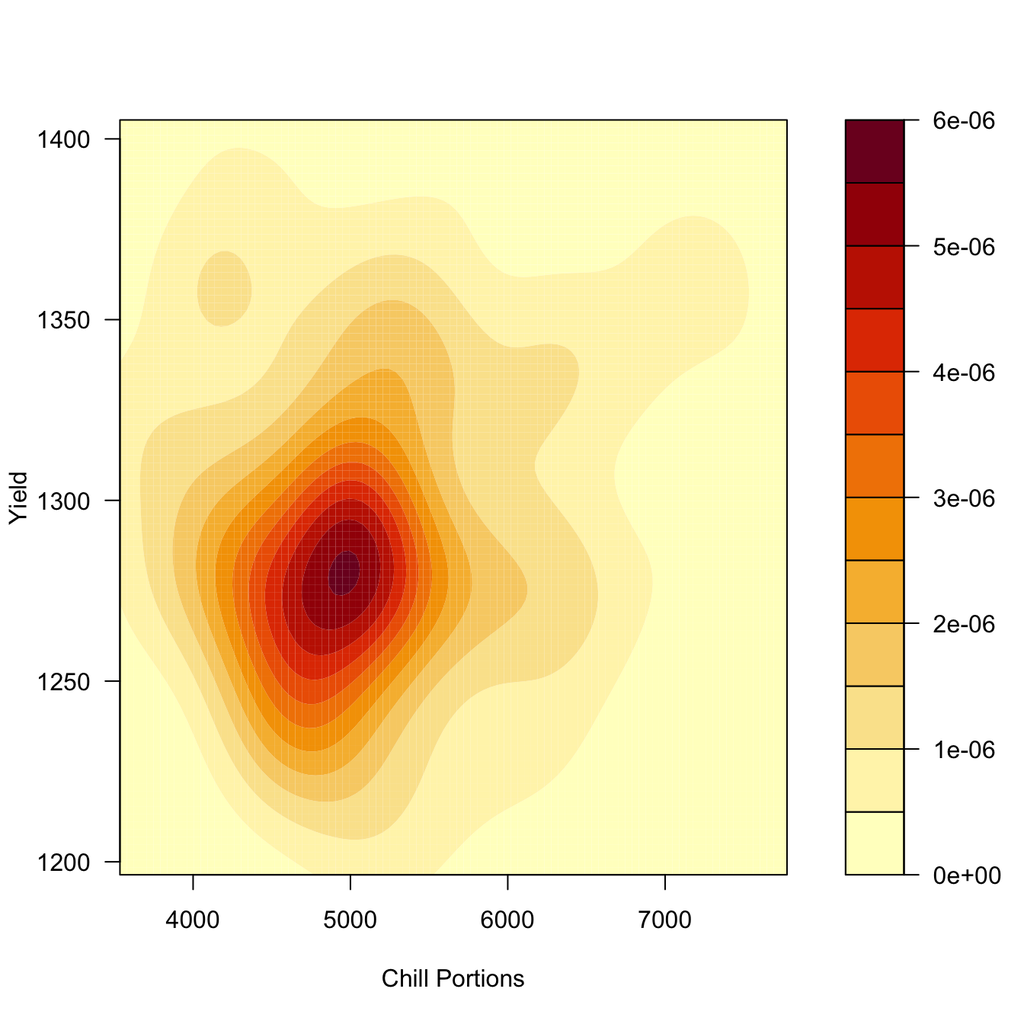

```
#> [1] "Density surface plot of Chill Portions (x) and yield (y)."
```

```r
pasitR::chillkernel(chill, yield)
```

`chillkernel()` shows a density surface plot of chill portions (x) and yield (y). The legend shows the value for the estimated density (z). The plot is made with the `filled.contour()` function of the `graphics()` package.

In `chillkernel()` the density (z) over the entire plot integrates to one, and therefore represents the relative probability of an observation (yield along y-axis) given a specific chill portion (along x-axis).

## Estimated yield given the expected chill

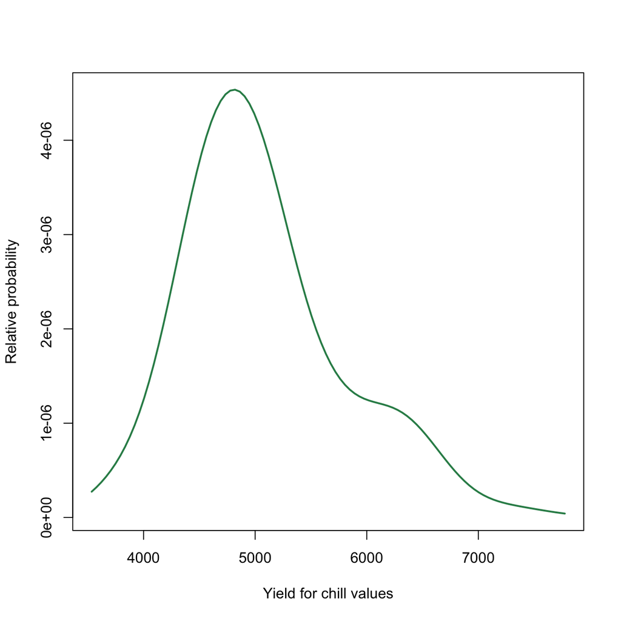

```
#> [1] "Estimated yield given expected chill."
```

```r
pasitR::chillkernelslice(chill, yield, expectedchill = 30)
```

## Chill portion intervals

`chillviolin()` determines different possible chill portion intervals by calculating the optimal interval width for chill portions using the `IQR()` function in the `stats()` package, after the Freedman-Diaconis rule (IQR = interquartile range). `Optimal interval width for our sample = 2 * interquartile range for our sample / (total number of observations for the interquartile range for our sample)^(1/3)`

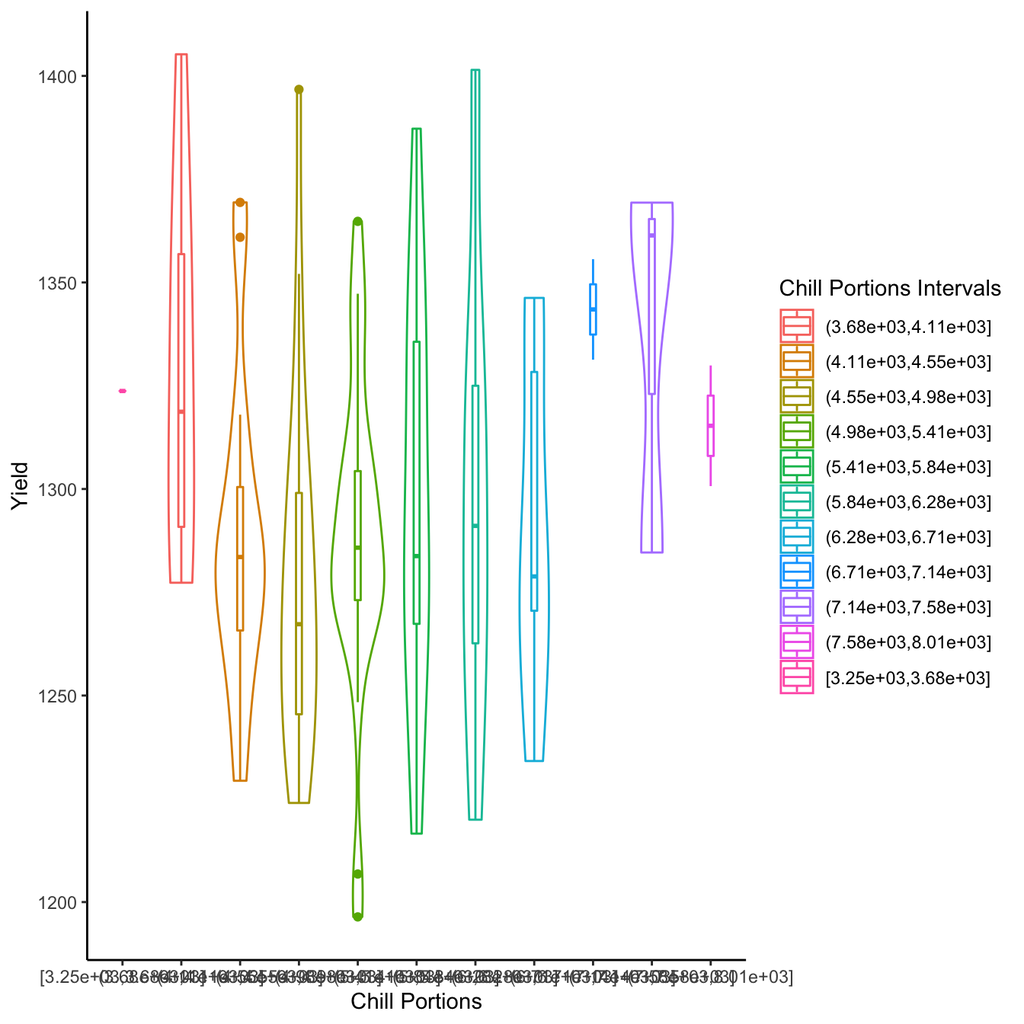

[output not shown]

```r
pasitR::chillviolin(chill, yield)
```

## Probability of yield given chill

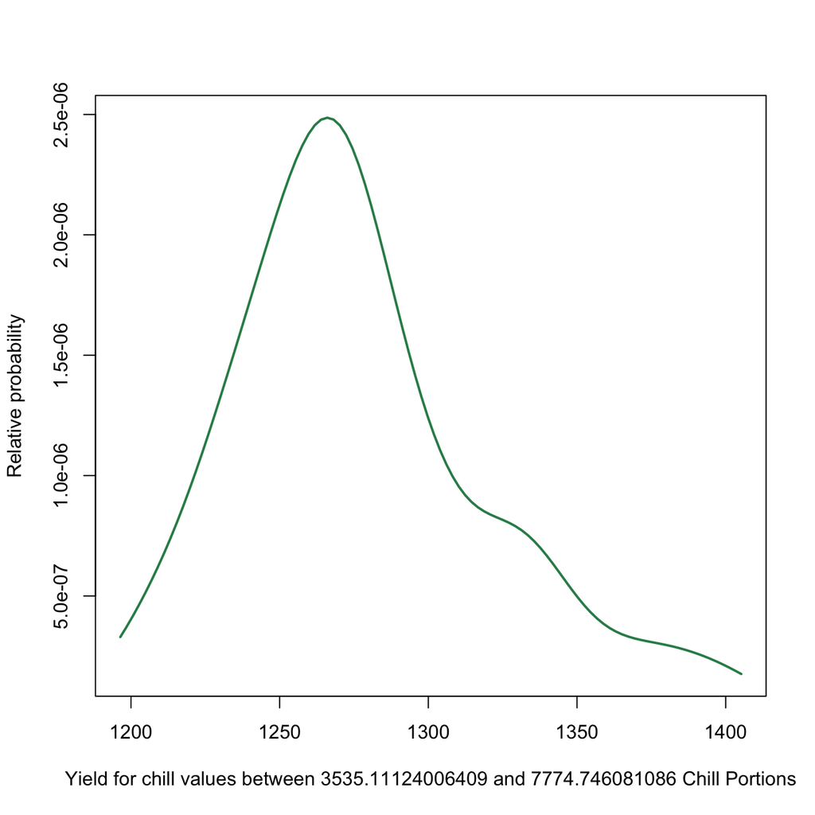

```
#> [1] "Relative probability (y) of yield for the given Chill Portions interval (x)."
```

```r
# min_chill
# is a value of the lowest expected amount of chill for which the yield should be estimated (must be < expectedhighchill).

#
# max_chill
# is a value of the highest expected amount of chill for which the yield should be estimated (must be > expectedlowchill).

pasitR::chillkernelslicerange(chill, yield, min_chill = min(chill), max_chill = max(chill))
```

`chillkernelslicerange()` plots the probabilities (shown along the y-axis) for the expected yield (shown along the x-axis). As with `chillkernelslice()` the probability values shown are relative, not absolute measures. They are the result of cuts through the density kernel `chillkernel()`, which integrates to 1.

## References

R Core Team (2017) R: A Language and Environment for Statistical Computing [R Version 3.4.1 (2017-06-30) “Single Candle”] 3.4.1.

Venables, W. N., and B. D. Ripley (2002) Modern Applied Statistics with S. Fourth Edition. New York: Springer.

Wickham, Hadley (2011) Plyr: Tools for Splitting, Applying and Combining Data, Version 1.4. Available Online at Cran. r-Project. Elegant Graphics for Data Analysis. Springer.